# Lab 2 - Data 202

Raven Warner

12 October 2025

# Purpose

- Examine the relationship between race, Christianity (relig), and income (rincome) in the United States using the `gss_cat` dataset. Religion serves as a fundamental principle and backbone for many social justice movements today. The moral values shaped by religious upbringing often influence advocacy for equity and justice within communities and across society. This study places a special emphasis on the intersection of income, race, and religion, focusing specifically on Christians. Future analyses could expand to include comparisons across other religions to further enhance this study. Primarily, my commentary on the results of this analysis will be featured in the *Reports* section.

## Imports

```r
# install the tidyverse package
# install.packages("tidyverse", repos = "http://cran.us.r-project.org")

# load the libraries needed for today's analyses
library(tidyverse)
library(dplyr)
library(critstats)

## update packages if needed; remove # to run code
# update.packages("package-name")
```

## Load dataset

```r
# ??gss_cat dataset documentation

# gss_cat - sample categorical variables from the General Social Survey
# year, age, marital, race, rincome, partyid, relig, denom, tvhours

gss <- gss_cat # assign dataset to main dataframe
```

## Initial Dataset Exploration

```r
# summary
summary(gss)
```

```
##       year               marital           age                    race
##  Min.   :2000   No answer    :   17   Min.   :18.00   Other         : 1959
##  1st Qu.:2002   Never married: 5416   1st Qu.:33.00   Black         : 3129
##  Median :2006   Separated    :  743   Median :46.00   White         :16395
##  Mean   :2007   Divorced     : 3383   Mean   :47.18   Not applicable:    0
##  3rd Qu.:2010   Widowed      : 1807   3rd Qu.:59.00
##  Max.   :2014   Married      :10117   Max.   :89.00
##                                       NA's   :76
##            rincome                   partyid            relig
##  $25000 or more:7363   Independent       :4119   Protestant:10846
##  Not applicable:7043   Not str democrat  :3690   Catholic  : 5124
##  $20000 - 24999:1283   Strong democrat   :3490   None      : 3523
##  $10000 - 14999:1168   Not str republican:3032   Christian :  689
##  $15000 - 19999:1048   Ind,near dem      :2499   Jewish    :  388
##  Refused       : 975   Strong republican :2314   Other     :  224
##  (Other)       :2603   (Other)           :2339   (Other)   :  689
##               denom          tvhours
##  Not applicable  :10072   Min.   : 0.000
##  Other           : 2534   1st Qu.: 1.000
##  No denomination : 1683   Median : 2.000
##  Southern baptist: 1536   Mean   : 2.981
##  Baptist-dk which: 1457   3rd Qu.: 4.000
##  United methodist: 1067   Max.   :24.000
##  (Other)         : 3134   NA's   :10146
```

```r
# glimpse
glimpse(gss)
```

```
## Rows: 21,483
## Columns: 9
## $ year    <int> 2000, 2000, 2000, 2000, 2000, 2000, 2000, 2000, 2000, 2000, 20…
## $ marital <fct> Never married, Divorced, Widowed, Never married, Divorced, Mar…
## $ age     <int> 26, 48, 67, 39, 25, 25, 36, 44, 44, 47, 53, 52, 52, 51, 52, 40…
## $ race    <fct> White, White, White, White, White, White, White, White, White,…
## $ rincome <fct> $8000 to 9999, $8000 to 9999, Not applicable, Not applicable, …
## $ partyid <fct> "Ind,near rep", "Not str republican", "Independent", "Ind,near…
## $ relig   <fct> Protestant, Protestant, Protestant, Orthodox-christian, None, …
## $ denom   <fct> "Southern baptist", "Baptist-dk which", "No denomination", "No…
## $ tvhours <int> 12, NA, 2, 4, 1, NA, 3, NA, 0, 3, 2, NA, 1, NA, 1, 7, NA, 3, 3…
```

```r
head(gss)
```

```
## # A tibble: 6 × 9
##    year marital         age race  rincome        partyid     relig denom tvhours
##   <int> <fct>         <int> <fct> <fct>          <fct>       <fct> <fct>   <int>
## 1  2000 Never married    26 White $8000 to 9999  Ind,near r… Prot… Sout…      12
## 2  2000 Divorced         48 White $8000 to 9999  Not str re… Prot… Bapt…      NA
## 3  2000 Widowed          67 White Not applicable Independent Prot… No d…       2
## 4  2000 Never married    39 White Not applicable Ind,near r… Orth… Not …       4
## 5  2000 Divorced         25 White Not applicable Not str de… None  Not …       1
## 6  2000 Married          25 White $20000 - 24999 Strong dem… Prot… Sout…      NA
```

```r
tail(gss)
```

```
## # A tibble: 6 × 9
##    year marital         age race  rincome        partyid     relig denom tvhours
##   <int> <fct>         <int> <fct> <fct>          <fct>       <fct> <fct>   <int>
## 1  2014 Widowed          75 White Don't know     Strong rep… Prot… Bapt…       4
## 2  2014 Widowed          89 White Not applicable Not str re… Prot… Unit…       3
## 3  2014 Divorced         56 White $25000 or more Independent None  Not …       4
## 4  2014 Never married    24 White $10000 - 14999 Ind,near d… None  Not …       4
## 5  2014 Never married    27 White $25000 or more Not str de… Cath… Not …      NA
## 6  2014 Widowed          71 White $20000 - 24999 Ind,near r… Prot… Other       2
```

## Part 2 - Dataset Cleaning/Modification and Analysis

- Modified the dataset to work within bounds of research analysis.
- Removed non-Christian survey answers (Assumption: For religion, “Christian” is the only value that counts as Christian. Protestant, Catholic, etc. were removed from the dataset)
- “Other” type answer were removed from the rincome (reported income) variable. I am only looking at answers with reported income, not “Don’t know” or “None” etc.
- Responses by self-reported “Black” and “White” individuals are the focus of this analysis. “Other” etc. was removed.
- Utilized the droplevels() function to remove filtered content from view

```r
gsd = gss_cat%>%
  na.omit() %>%
  select(year, race, rincome , relig, age) %>%
  filter(relig %in% c("Christian"))  %>% # filter relig column to only include self-reported Christian participants
  filter(race %in% c("White", "Black")) %>% # filter race column to only include self-reported Black or White participants
  filter(!rincome %in% c("No answer", "Refused", "Not applicable", "Don't know")) # filter rincome column to only include actual income ranges only. Removed "Other" type answers for sake of study



gsd = droplevels(gsd) #removed multiple variable columns, and NA values
gsd
```

```
## # A tibble: 223 × 5
##     year race  rincome        relig       age
##    <int> <fct> <fct>          <fct>     <int>
##  1  2000 White $25000 or more Christian    36
##  2  2000 White $25000 or more Christian    54
##  3  2000 White $20000 - 24999 Christian    31
##  4  2000 White $25000 or more Christian    42
##  5  2000 White $25000 or more Christian    36
##  6  2000 Black $25000 or more Christian    36
##  7  2000 Black $10000 - 14999 Christian    31
##  8  2000 White $25000 or more Christian    48
##  9  2000 White $15000 - 19999 Christian    27
## 10  2000 White $25000 or more Christian    45
## # ℹ 213 more rows
```

```r
# Archived code (not for grading, personal use only)
  #filter(!relig %in% c("No answer", "Don't know", "None", "Not applicable", "Other")) %>%
```

### Create a table of variables from filtered dataset

- The table() function counts how many times each unique value appears in a column, creating a frequency table.
- The following shows the number of respondents in each race, income category, and religious group (Christian), respectively.

```r
table(gsd$race)
```

```
##
## Black White
##    51   172
```

```r
table(gsd$rincome)
```

```
##
## $25000 or more $20000 - 24999 $15000 - 19999 $10000 - 14999  $8000 to 9999
##            119             23             11             23              5
##  $7000 to 7999  $6000 to 6999  $5000 to 5999  $4000 to 4999  $3000 to 3999
##              7              5              7              5              5
##  $1000 to 2999       Lt $1000
##              7              6
```

```r
table(gsd$relig)
```

```
##
## Christian
##       223
```

### Create a table of variables from filtered dataset (proportions)

- Around 77% of the respondents are White, while only around 22.8% of respondents are Black.
- Over 53% of the respondents make over $25,000. The next overall highest category is $20,000-24,999.

```r
prop.table(table(gsd$race))
```

```
##
##     Black     White
## 0.2286996 0.7713004
```

```r
prop.table(table(gsd$rincome))
```

```
##
## $25000 or more $20000 - 24999 $15000 - 19999 $10000 - 14999  $8000 to 9999
##     0.53363229     0.10313901     0.04932735     0.10313901     0.02242152
##  $7000 to 7999  $6000 to 6999  $5000 to 5999  $4000 to 4999  $3000 to 3999
##     0.03139013     0.02242152     0.03139013     0.02242152     0.02242152
##  $1000 to 2999       Lt $1000
##     0.03139013     0.02690583
```

```r
prop.table(table(gsd$relig))
```

```
##
## Christian
##         1
```

## Visualize

- The visualizations help see differences between Black and White Christians in income distribution.

Distribution of Race - Out of the 223 Christian respondents, 172 reported a race of “White” while 51 reported “Black” as their race.

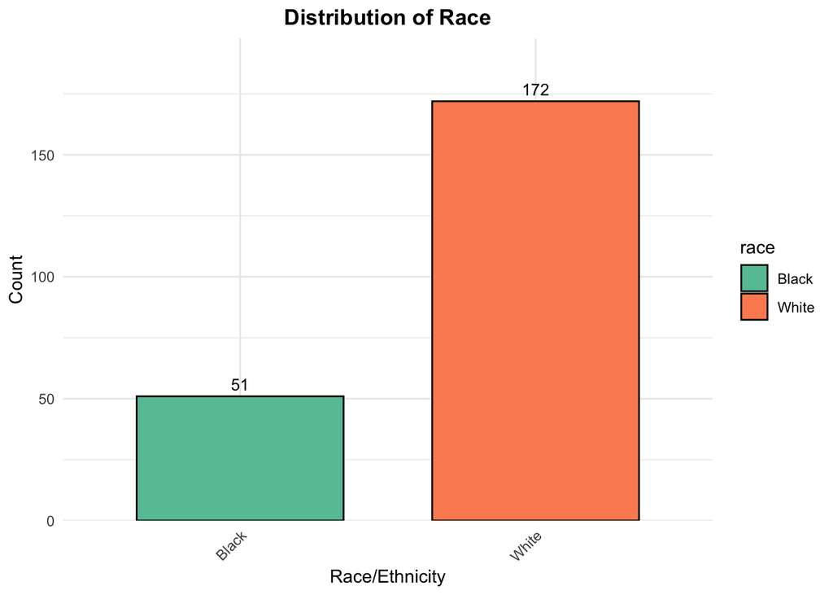

```r
ggplot(gsd, aes(x = race, fill = race)) +
  geom_bar(width = 0.7, color = "black") +
  geom_text(stat = "count", aes(label = after_stat(count)),
            vjust = -0.5, color = "black", size = 3.5) +
  scale_fill_brewer(palette = "Set2") +
  labs(x = "Race/Ethnicity", y = "Count", title = "Distribution of Race") +
  theme_minimal() +
  theme(
    axis.text.x = element_text(angle = 45, hjust = 1),
    legend.position = "right",
    plot.title = element_text(hjust = 0.5, face = "bold")
  ) +
  scale_y_continuous(expand = expansion(mult = c(0, 0.15)))
```

Distribution of Religion - There are approximately 223 Christians in the abbreviated dataset.

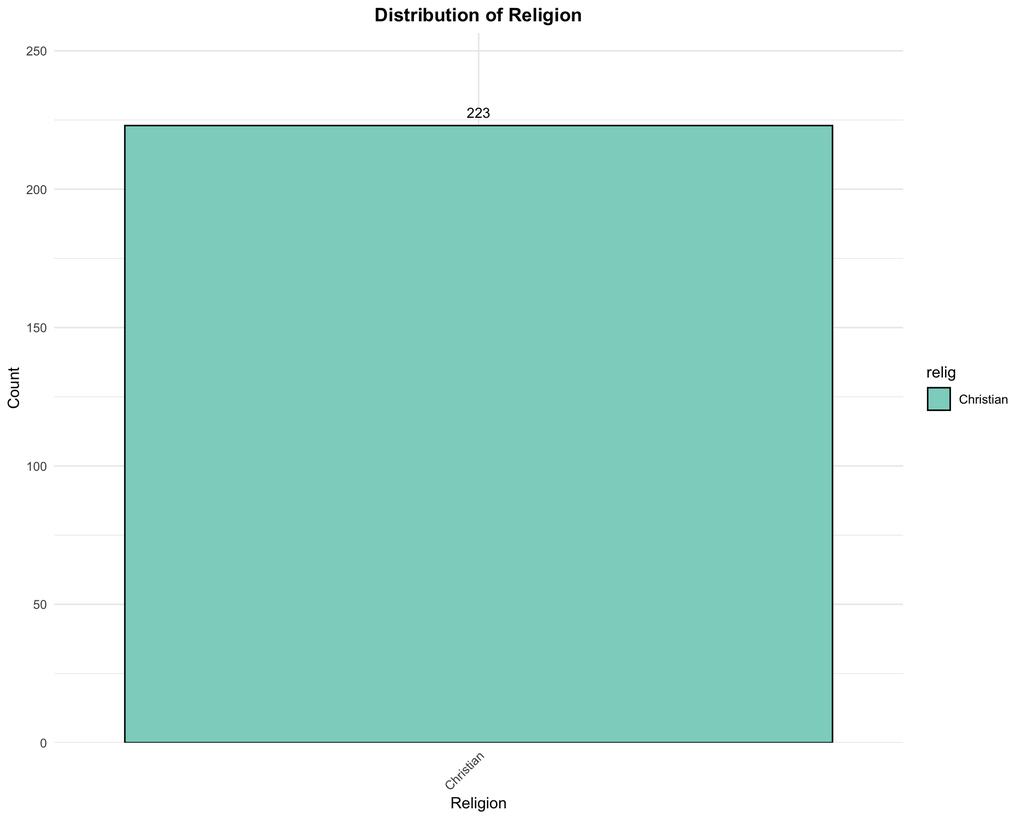

```r
ggplot(gsd, aes(x = relig, fill = relig)) +
  geom_bar(width = 1,  color = "black") +
  geom_text(stat = "count", aes(label = after_stat(count)),
            vjust = -0.8, color = "black", size = 3.5) +
  scale_fill_brewer(palette = "Set3") +
  labs(x = "Religion", y = "Count", title = "Distribution of Religion") +
  theme_minimal() +
  theme(
    axis.text.x = element_text(angle = 45, hjust = 1),
    legend.position = "right",
    plot.title = element_text(hjust = 0.5, face = "bold")
  ) +
  scale_y_continuous(expand = expansion(mult = c(0, .15)))
```

### Proportions of Reported Income by Race (Christian Respondents) - Supplementary Visual

This chart shows the percentages of the reported income by race among Christian respondents.

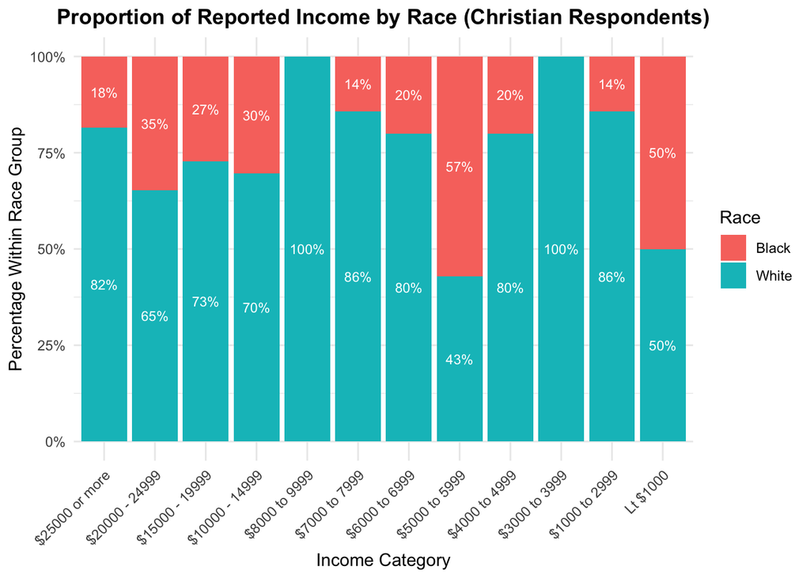

```r
library(dplyr)
library(ggplot2)
library(scales)

# Compute proportions by income within race
gsd_prop <- gsd %>%
  count(rincome, race) %>%
  group_by(rincome) %>%
  mutate(prop = n / sum(n))

# Plot stacked 100% bar chart with percentage labels
ggplot(gsd_prop, aes(x = rincome, y = prop, fill = race)) +
  geom_col(position = "fill") +
  geom_text(
    aes(label = percent(prop, accuracy = 1)),        # show percentage
    position = position_fill(vjust = 0.5),           # center inside each segment
    color = "white",
    size = 3
  ) +
  scale_y_continuous(labels = percent) +
  labs(
    title = "Proportion of Reported Income by Race (Christian Respondents)",
    x = "Income Category",
    y = "Percentage Within Race Group",
    fill = "Race"
  ) +
  theme_minimal() +
  theme(
    axis.text.x = element_text(angle = 45, hjust = 1),
    plot.title = element_text(face = "bold", hjust = 0.5)
  )
```

### Actual Counts of Reported Income by Race (Christian Respondents) - Supplementary Visual

- This chart shows the actual counts of the reported income by race among Christian respondents. This chart is to help supplement the proportions on the above chart, providing more insight into the actual count associated with them. This helps to see the numbers more tangibly.

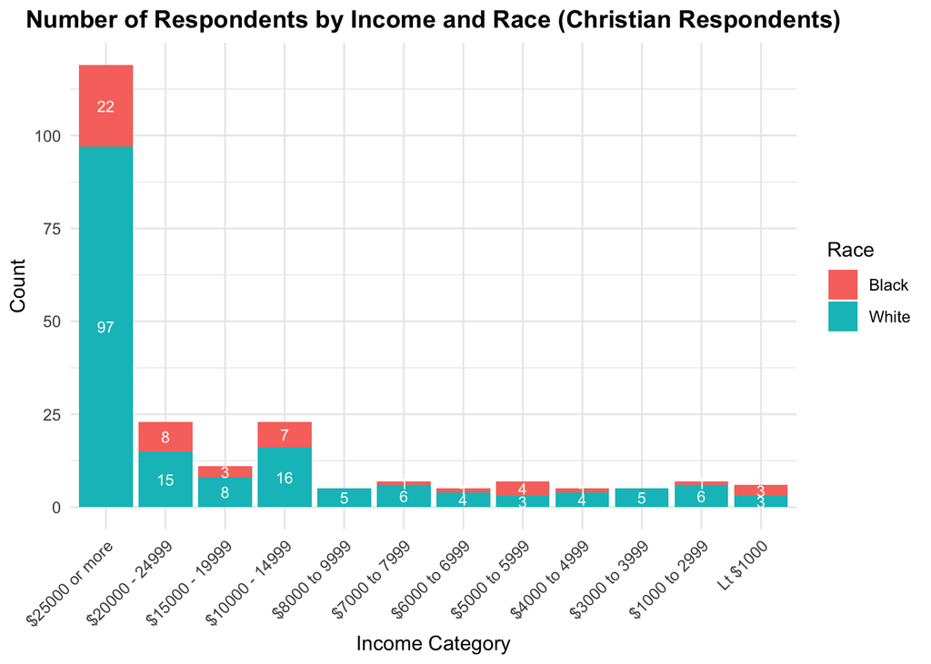

```r
library(ggplot2)

ggplot(gsd, aes(x = rincome, fill = race)) +
  geom_bar() +  # ggplot counts occurrences automatically
  geom_text(
    stat = "count",                    # counts computed by ggplot
    aes(label = ..count..),            # ..count.. accesses the computed count
    position = position_stack(vjust = 0.5),
    color = "white",
    size = 3
  ) +
  labs(
    title = "Number of Respondents by Income and Race (Christian Respondents)",
    x = "Income Category",
    y = "Count",
    fill = "Race"
  ) +
  theme_minimal() +
  theme(
    axis.text.x = element_text(angle = 45, hjust = 1),
    plot.title = element_text(face = "bold", hjust = 0.5)
  )
```

# Analysis

Chi-squared test results - Not statistically significant difference in income distribution between Black and White Christians in this sample (p > 0.05).

```r
chisq.test(table(gsd$race, gsd$rincome))
```

```
##
##  Pearson's Chi-squared test
##
## data:  table(gsd$race, gsd$rincome)
## X-squared = 14.775, df = 11, p-value = 0.193
```

Load the descr and Hmisc libraries. Install packages as needed.

```r
#install.packages("descr")
#install.packages("Hmisc")
library(descr)
library(Hmisc)
```

## Sample size

Get a count of the sample size. - This is the count of the total respondents for the abbreviated dataset.

```r
count(gsd)
```

```
## # A tibble: 1 × 1
##       n
##   <int>
## 1   223
```

## Relative frequencies

Get relative frequencies by the `race` variable.

```r
gsd %>%
  count(race) %>%
  mutate(prop = prop.table(n))
```

```
## # A tibble: 2 × 3
##   race      n  prop
##   <fct> <int> <dbl>
## 1 Black    51 0.229
## 2 White   172 0.771
```

Get relative frequencies by the `relig`` variable.

```r
gsd %>%
  count(relig) %>%
  mutate(prop = prop.table(n))
```

```
## # A tibble: 1 × 3
##   relig         n  prop
##   <fct>     <int> <dbl>
## 1 Christian   223     1
```

Get relative frequencies by the `rincome``` variable.

```r
gsd %>%
  count(rincome) %>%
  mutate(prop = prop.table(n))
```

```
## # A tibble: 12 × 3
##    rincome            n   prop
##    <fct>          <int>  <dbl>
##  1 $25000 or more   119 0.534
##  2 $20000 - 24999    23 0.103
##  3 $15000 - 19999    11 0.0493
##  4 $10000 - 14999    23 0.103
##  5 $8000 to 9999      5 0.0224
##  6 $7000 to 7999      7 0.0314
##  7 $6000 to 6999      5 0.0224
##  8 $5000 to 5999      7 0.0314
##  9 $4000 to 4999      5 0.0224
## 10 $3000 to 3999      5 0.0224
## 11 $1000 to 2999      7 0.0314
## 12 Lt $1000           6 0.0269
```

## Crosstab

Get a crosstab of the `race` and `rincome` variables.

```r
crosstab(gsd$rincome, gsd$race, plot=F)
```

```
##    Cell Contents
## |-------------------------|
## |                   Count |
## |-------------------------|
##
## =======================================
##                   gsd$race
## gsd$rincome       Black   White   Total
## ---------------------------------------
## $25000 or more       22      97     119
## ---------------------------------------
## $20000 - 24999        8      15      23
## ---------------------------------------
## $15000 - 19999        3       8      11
## ---------------------------------------
## $10000 - 14999        7      16      23
## ---------------------------------------
## $8000 to 9999         0       5       5
## ---------------------------------------
## $7000 to 7999         1       6       7
## ---------------------------------------
## $6000 to 6999         1       4       5
## ---------------------------------------
## $5000 to 5999         4       3       7
## ---------------------------------------
## $4000 to 4999         1       4       5
## ---------------------------------------
## $3000 to 3999         0       5       5
## ---------------------------------------
## $1000 to 2999         1       6       7
## ---------------------------------------
## Lt $1000              3       3       6
## ---------------------------------------
## Total                51     172     223
## =======================================
```

Standardize the frequencies.

```r
crosstab(gsd$rincome, gsd$race, plot=F, prop.c=T)
```

```
##    Cell Contents
## |-------------------------|
## |                   Count |
## |          Column Percent |
## |-------------------------|
##
## =======================================
##                   gsd$race
## gsd$rincome       Black   White   Total
## ---------------------------------------
## $25000 or more      22      97     119
##                   43.1%   56.4%
## ---------------------------------------
## $20000 - 24999       8      15      23
##                   15.7%    8.7%
## ---------------------------------------
## $15000 - 19999       3       8      11
##                    5.9%    4.7%
## ---------------------------------------
## $10000 - 14999       7      16      23
##                   13.7%    9.3%
## ---------------------------------------
## $8000 to 9999        0       5       5
##                    0.0%    2.9%
## ---------------------------------------
## $7000 to 7999        1       6       7
##                    2.0%    3.5%
## ---------------------------------------
## $6000 to 6999        1       4       5
##                    2.0%    2.3%
## ---------------------------------------
## $5000 to 5999        4       3       7
##                    7.8%    1.7%
## ---------------------------------------
## $4000 to 4999        1       4       5
##                    2.0%    2.3%
## ---------------------------------------
## $3000 to 3999        0       5       5
##                    0.0%    2.9%
## ---------------------------------------
## $1000 to 2999        1       6       7
##                    2.0%    3.5%
## ---------------------------------------
## Lt $1000             3       3       6
##                    5.9%    1.7%
## ---------------------------------------
## Total               51     172     223
##                   22.9%   77.1%
## =======================================
```

Create a crosstab with raw frequencies.

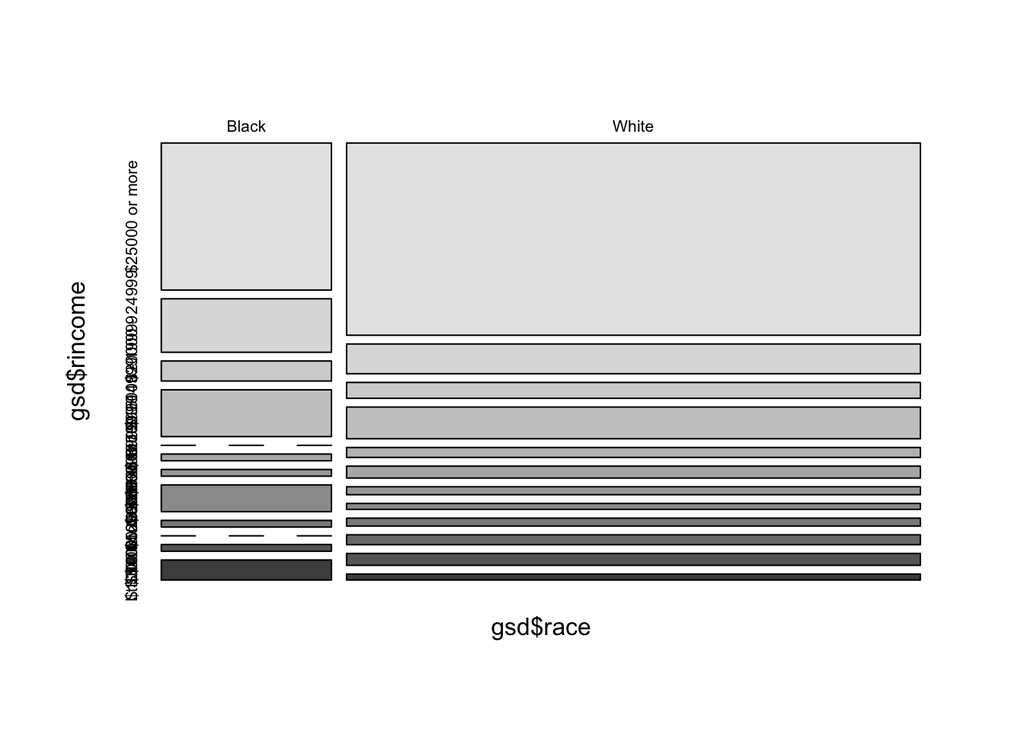

```
##    Cell Contents
## |-------------------------|
## |                   Count |
## |-------------------------|
##
## =======================================
##                   gsd$race
## gsd$rincome       Black   White   Total
## ---------------------------------------
## $25000 or more       22      97     119
## ---------------------------------------
## $20000 - 24999        8      15      23
## ---------------------------------------
## $15000 - 19999        3       8      11
## ---------------------------------------
## $10000 - 14999        7      16      23
## ---------------------------------------
## $8000 to 9999         0       5       5
## ---------------------------------------
## $7000 to 7999         1       6       7
## ---------------------------------------
## $6000 to 6999         1       4       5
## ---------------------------------------
## $5000 to 5999         4       3       7
## ---------------------------------------
## $4000 to 4999         1       4       5
## ---------------------------------------
## $3000 to 3999         0       5       5
## ---------------------------------------
## $1000 to 2999         1       6       7
## ---------------------------------------
## Lt $1000              3       3       6
## ---------------------------------------
## Total                51     172     223
## =======================================
```

```r
crosstab(gsd$rincome, gsd$race, plot=T)
```

Gather the expected values.

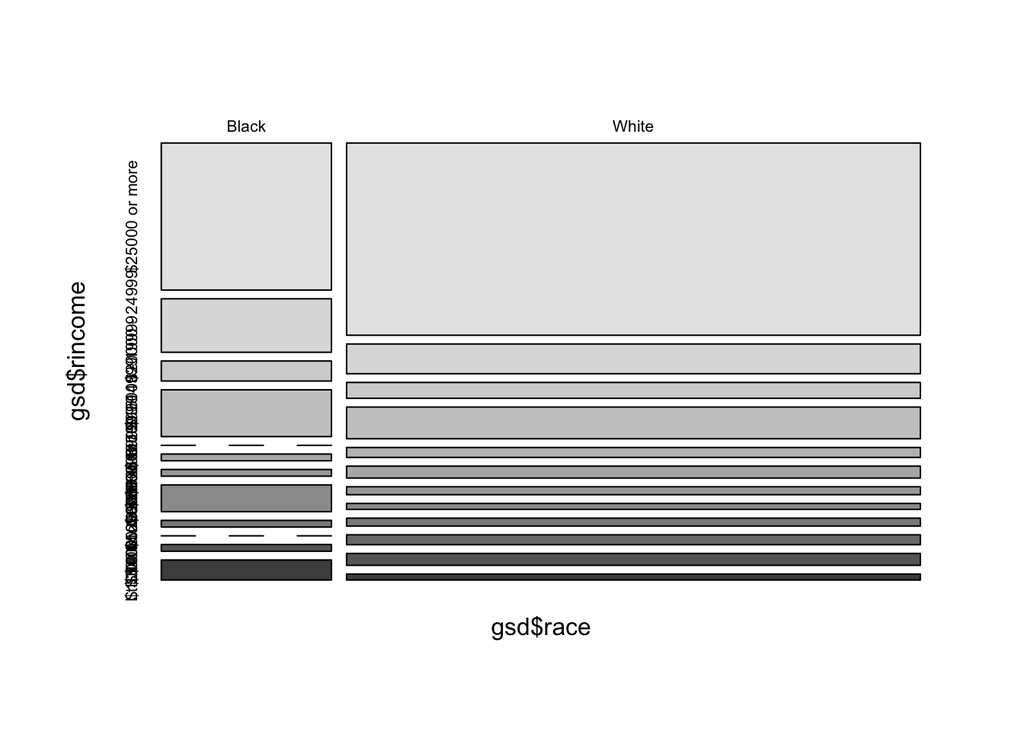

```
##    Cell Contents
## |-------------------------|
## |                   Count |
## |         Expected Values |
## |-------------------------|
##
## =======================================
##                   gsd$race
## gsd$rincome       Black   White   Total
## ---------------------------------------
## $25000 or more       22      97     119
##                    27.2    91.8
## ---------------------------------------
## $20000 - 24999        8      15      23
##                     5.3    17.7
## ---------------------------------------
## $15000 - 19999        3       8      11
##                     2.5     8.5
## ---------------------------------------
## $10000 - 14999        7      16      23
##                     5.3    17.7
## ---------------------------------------
## $8000 to 9999         0       5       5
##                     1.1     3.9
## ---------------------------------------
## $7000 to 7999         1       6       7
##                     1.6     5.4
## ---------------------------------------
## $6000 to 6999         1       4       5
##                     1.1     3.9
## ---------------------------------------
## $5000 to 5999         4       3       7
##                     1.6     5.4
## ---------------------------------------
## $4000 to 4999         1       4       5
##                     1.1     3.9
## ---------------------------------------
## $3000 to 3999         0       5       5
##                     1.1     3.9
## ---------------------------------------
## $1000 to 2999         1       6       7
##                     1.6     5.4
## ---------------------------------------
## Lt $1000              3       3       6
##                     1.4     4.6
## ---------------------------------------
## Total                51     172     223
## =======================================
```

```r
crosstab(gsd$rincome, gsd$race,
         expected=T, #Add expected frequency to each cell
         plot=T)
```

### Add the chi-square contributions.

- In this analysis, The Black respondents making $25,000+ are less than expected, so this group “stands out” a bit. The White respondents making $25,000+ are slightly more than expected, but not as surprising. In 7 out of 12 income categories, Black respondents are fewer than expected, meaning that in most income ranges, Black respondents are underrepresented compared to what we would expect if race didn’t affect income.

```r
crosstab(gsd$rincome, gsd$race,
         expected=T, #Add expected frequency to each cell
         prop.chisq = T, #Total contribution of each cell
         plot=F)
```

```
##    Cell Contents
## |-------------------------|
## |                   Count |
## |         Expected Values |
## | Chi-square contribution |
## |-------------------------|
##
## =======================================
##                   gsd$race
## gsd$rincome       Black   White   Total
## ---------------------------------------
## $25000 or more       22      97     119
##                    27.2    91.8
##                   0.999   0.296
## ---------------------------------------
## $20000 - 24999        8      15      23
##                     5.3    17.7
##                   1.427   0.423
## ---------------------------------------
## $15000 - 19999        3       8      11
##                     2.5     8.5
##                   0.093   0.028
## ---------------------------------------
## $10000 - 14999        7      16      23
##                     5.3    17.7
##                   0.576   0.171
## ---------------------------------------
## $8000 to 9999         0       5       5
##                     1.1     3.9
##                   1.143   0.339
## ---------------------------------------
## $7000 to 7999         1       6       7
##                     1.6     5.4
##                   0.226   0.067
## ---------------------------------------
## $6000 to 6999         1       4       5
##                     1.1     3.9
##                   0.018   0.005
## ---------------------------------------
## $5000 to 5999         4       3       7
##                     1.6     5.4
##                   3.595   1.066
## ---------------------------------------
## $4000 to 4999         1       4       5
##                     1.1     3.9
##                   0.018   0.005
## ---------------------------------------
## $3000 to 3999         0       5       5
##                     1.1     3.9
##                   1.143   0.339
## ---------------------------------------
## $1000 to 2999         1       6       7
##                     1.6     5.4
##                   0.226   0.067
## ---------------------------------------
## Lt $1000              3       3       6
##                     1.4     4.6
##                   1.931   0.573
## ---------------------------------------
## Total                51     172     223
## =======================================
```

## Reports (Parts 1-2)

**- Analysis, commentary, and lab findings are located in *this* section.**

### Report 1.1 - What dataset have you decided to use?

- I am using the **gss_cat dataset.** - A sample of categorical variables from the General Social Survey. The General Social Survey (GSS) is a biennial survey that collects data on American society to monitor and explain trends in opinions, attitudes, and behaviors.

### Report 1.3 - What is your research question?

- “How do income levels differ between Black and White Christians in the U.S., and what do these differences reveal about racial economic disparities within Christian communities?”

### Report 1.4 - What is your data analysis plan? Please be descriptive.

### Data Analysis Plan

1. **Filter the dataset**
   - Keep only Christian respondents. Note: Christian responses only consisted of those who reported “Christian” for their religion.
   - Focus only on Black and White respondents. Note: I wanted to specficially focus on Black and White respondents.
   - Remove non-responses and unclear income answers. Note: At this time, “other” type responses were not relevant.
2. **Explore the data**
   - Use exploratory functionality like View, glimpse() and table() to obtain further understanding of the dataset, speficially in regard to the following variables: race, relig, rincome.
   - Calculate proportions to see relative frequencies.
3. **Visualize the data**
   - Create charts for race and religion distributions.
   - Create charts charts for income by race, showing both **percentages** and **actual counts**.
4. **Analyze relationships**
   - Create crosstabs of `race` × `rincome`.
   - Examine **observed counts vs. expected counts**.
   - Calculate **chi-square contributions** to see which income-race cells differ most from expectation.
5. **Statistical test**
   - Conduct a **chi-squared test** to check if income distribution differs significantly between Black and White Christians.
6. **Interpret results**
   - Compare observed vs. expected counts.
   - Note group over/underrepresentation.
   - Acknowledge limitations due to small sample size.

### Report 1.5 - What are some potential limitations for your analysis?

- While more specific reflections are captured in 1.10, I took note initially pre-analysis, that the number of Black respondents is much smaller than White respondents. This imbalance could make results appear as if White Christian respondents earn more, even if that reflects overrepresentation rather than reality. From a social justice perspective, this highlights how minority voices and experiences are often underrepresented in datasets, which can hide inequities and the ways that underrepresentation affects livelihoods and opportunities in the U.S for the marginalized/minority communities.

### Report 1.7 - Please include all code used to clean and manipulate the two variables?

- All code used to clean and manipulate is shown and annotated for clarity, above the reports section.

### Report 1.8 - What relationship, if any, exists between the two variables?

- After exploring the data, I realized that while there is likely a more pronounced relationship between race, income, and religion in the broader population, my analysis did not capture much of a relationship within this subset. The limitations of the dataset, such as its small size and the imbalance between Black and White respondents, likely influenced these results more than the actual disparities that exist in the U.S. The chi-squared test yielded a p-value of 0.193, which is above 0.05, indicating no statistically significant association between race and income in this specific sample of Black and White Christians with reported income. Additionally, the full gss_cat dataset included many respondents who reported “None,” “Refused,” “Don’t know,” or “Not Applicable.” While these responses are not numerical, they still convey important information about income patterns; for example, “None” could indicate $0 income. Observed versus expected counts show that 7 out of 12 income ranges for Black respondents were lower than expected, while the remaining ranges were higher. Ultimately, there was not much of a clear relationship to be seen, given the small, imbalanced sample. Considering the diversity of the U.S., excluding the “Other” category likely omitted additional minority and marginalized individuals who could have contributed to a more balanced and representative sample.

### Report 1.9 - How do these findings relate to your research question and theory?

- When I first created my research question, I was genuinely excited to explore how religion might impact income, with an added emphasis on race. As someone who values Christianity and the concepts of faith, grace, and spiritual blessings, I hoped to see whether the data would reflect that Christians are “blessed” not only spiritually but also financially. To be honest, the results were very underwhelming, and I questioned redoing the entire lab. The findings do not provide strong evidence to support a correlation between religious affiliation and financial stability or affluence.
- The data highlighted the **lack of a clear relationship** between the variables I analyzed, race, income, and Christianity, rather than supporting the idea of an actual connection. Specifically, my analysis focused on those respondents who self-reported as Black and White Christians. Though, a broader comparison including non-Christians or agnostic individuals would likely provide a more complete picture. A picture that would likely speak more in-depth to the relationship that must exist between race, rincome, and relig.
- Contextually, I chose to focus on religion in relation to income and race because spirituality has historically fueled social justice movements in the U.S. For example, think of figures like **Martin Luther King Jr., C.T. Vivian**, or more recently, **Pastor Jamal Bryant**, who led a national boycott against Target to protest scaling back diversity, equity, and inclusion initiatives. My goal was to see if there might be a “divine correlation” between income, race, and Christianity visible in the data that could hypothetically inform efforts to support those advancing social justice. After all, typically money and other financial resources are essential to sustaining such work, and I was curious whether the dataset reflected that potential connection. While my specific analysis did not reveal a correlation, it highlighted the importance of having sound, balanced, and clean data when conducting studies like this. I am concerned that skewed data, particularly underrepresentation of certain groups, can lead to decisions and outcomes that unfairly disadvantage those affected.

### Report 1.10 - What limitations exist as a result of the data analysis?

- **Small sample size:** - Only 223 respondents were included, with 51 Black and 172 White participants, which limits the statistical power and generalizability of the results. The imbalanced group of White and Black respondents likely affect the comparisons and observed patterns amongst the respondent data.
- **Christian-only focus:** Creating a subset of the initial dataset to only include self-reported Christians likely means the findings cannot be generalized to other religious groups or the broader population. Furthermore, it brings on the question of what it means to be a Christian to some individuals. That definition, by individual, is likely skewed or varies among each and every respondent. Therefore, what I may define as Chrisian in this study, may not directly align with how a respondent defined Chrisian. Therefore, in comparison to my perspective, there could be more or less Christians amongst the Black and White individuals, but were not explicitiy stated or reported due to invidiual understanding.
- **Categorical income ranges:** Using income ranges rather than exact income values reduces precision and may mask finer differences in income distribution. I was not able to do numerical comparisons with the income ranges, verses exact income values, and that significantly limited my ability to analyze further without fabricating income.
- **Observational data:** The data is self-reported, and humans come with error and bias, therefore further limiting the dataset.